# R markdown page with bootstrap 4

Danielle J. Navarro

12/08/2021

```r
library(bs4cards)

locate_thumbnail <- function(x) {
  system.file("extdata", "thumbnail", paste0(x, ".jpg"), package = "bs4cards")
}
locate_gallery <- function(x) {
  paste0("https://art.djnavarro.net/gallery/", x)
}

galleries
```

```
## # A tibble: 7 × 5
##   long_name              short_name   date       blurb             paintbrushes
##   <chr>                  <chr>        <chr>      <chr>             <chr>
## 1 Ash Cloud and Blood    ash          2021-07-17 Simulated waterc… ggplot2
## 2 Ghosts on Marble Paper ghosts       2021-01-09 Abstract landsca… ambient
## 3 Ice Floes              ice-floes    2021-01-19 Abstract iceberg… ambient
## 4 Native Flora           native-flora 2021-02-10 Collections of s… ggplot2 flam…
## 5 Silhouettes            silhouettes  2021-01-24 Trees generated … ggplot2 rcpp…
## 6 Track Marks            track-marks  2020-09-20 Voronoi tessella… ggplot2 rcpp
## 7 Viewports              viewports    2021-02-28 Simple masks wit… ggplot2 flam…
```

```r
galleries %>%
  cards(
    header = blurb,
    footer = blurb,
    #title = long_name,
    text = blurb,
    image = locate_thumbnail(short_name),
    width = "medium",
    layout = "label-below"
  )
```

Simulated watercolours in ggplot2 using the transparent polygon method

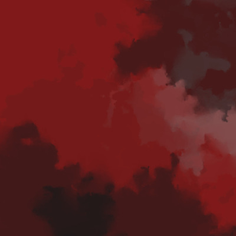

Simulated watercolours in ggplot2 using the transparent polygon method

Simulated watercolours in ggplot2 using the transparent polygon method

Abstract landscapes generated using ambient

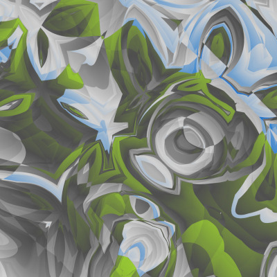

Abstract landscapes generated using ambient

Abstract landscapes generated using ambient

Abstract icebergs generated using ambient

[figure not shown]

Abstract icebergs generated using ambient

Abstract icebergs generated using ambient

Collections of small flametrees that resemble branching plants

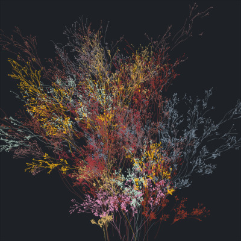

Collections of small flametrees that resemble branching plants

Collections of small flametrees that resemble branching plants

Trees generated in flametree with random walk backgrounds

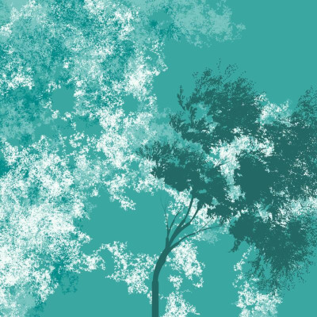

Trees generated in flametree with random walk backgrounds

Trees generated in flametree with random walk backgrounds

Voronoi tessellations with seed points sampled from an iterated function system

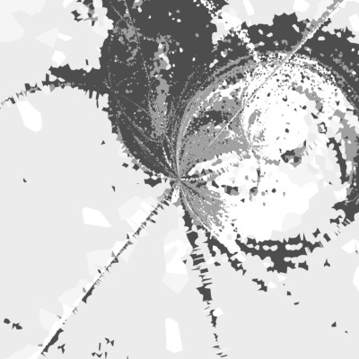

Voronoi tessellations with seed points sampled from an iterated function system

Voronoi tessellations with seed points sampled from an iterated function system

Simple masks with ggfx using flametree-generated textures

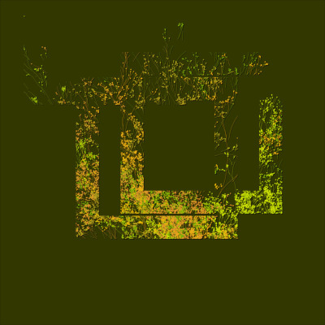

Simple masks with ggfx using flametree-generated textures

Simple masks with ggfx using flametree-generated textures